# Supervised Learning : Implementing Shapley Additive Explanations for Interpreting Feature Contributions in Penalized Cox Regression

### 1.6.2 Cox Regression with No Penalty

```python
##################################
# Formulating the Cox Regression model
# with No Penalty and generating the summary
##################################
cirrhosis_survival_coxph_L1_0_L2_0 = CoxPHFitter()
cirrhosis_survival_coxph_L1_0_L2_0.fit(cirrhosis_survival_train_modeling, duration_col='N_Days', event_col='Status')
cirrhosis_survival_coxph_L1_0_L2_0.summary
```

| covariate | coef | exp(coef) | se(coef) | coef lower 95% | coef upper 95% | exp(coef) lower 95% | exp(coef) upper 95% | cmp to | z | p | -log2(p) |
| --- | --- | --- | --- | --- | --- | --- | --- | --- | --- | --- | --- |
| Age | 0.376767 | 1.457565 | 0.138099 | 0.106098 | 0.647436 | 1.111931 | 1.910636 | 0.0 | 2.728240 | 0.006367 | 7.295096 |
| Bilirubin | 0.762501 | 2.143630 | 0.217243 | 0.336713 | 1.188289 | 1.400337 | 3.281461 | 0.0 | 3.509901 | 0.000448 | 11.123334 |
| Cholesterol | 0.061307 | 1.063225 | 0.163017 | -0.258200 | 0.380814 | 0.772441 | 1.463476 | 0.0 | 0.376078 | 0.706859 | 0.500505 |
| Albumin | -0.121698 | 0.885416 | 0.150453 | -0.416580 | 0.173184 | 0.659298 | 1.189085 | 0.0 | -0.808879 | 0.418585 | 1.256408 |
| Copper | 0.106671 | 1.112568 | 0.166238 | -0.219149 | 0.432492 | 0.803202 | 1.541093 | 0.0 | 0.641678 | 0.521083 | 0.940416 |
| Alk_Phos | 0.009525 | 1.009570 | 0.149078 | -0.282664 | 0.301713 | 0.753773 | 1.352173 | 0.0 | 0.063890 | 0.949058 | 0.075432 |
| SGOT | 0.175013 | 1.191261 | 0.155532 | -0.129825 | 0.479850 | 0.878249 | 1.615832 | 0.0 | 1.125249 | 0.260483 | 1.940736 |
| Tryglicerides | 0.134283 | 1.143716 | 0.138146 | -0.136478 | 0.405044 | 0.872425 | 1.499369 | 0.0 | 0.972036 | 0.331032 | 1.594955 |
| Platelets | -0.039691 | 0.961087 | 0.129440 | -0.293388 | 0.214007 | 0.745733 | 1.238631 | 0.0 | -0.306634 | 0.759122 | 0.397596 |
| Prothrombin | 0.359660 | 1.432843 | 0.139796 | 0.085665 | 0.633656 | 1.089441 | 1.884487 | 0.0 | 2.572748 | 0.010089 | 6.631007 |
| Drug | -0.236093 | 0.789708 | 0.250917 | -0.727881 | 0.255696 | 0.482931 | 1.291360 | 0.0 | -0.940919 | 0.346746 | 1.528048 |
| Sex | 0.088317 | 1.092335 | 0.354036 | -0.605581 | 0.782216 | 0.545757 | 2.186311 | 0.0 | 0.249459 | 0.803006 | 0.316517 |
| Ascites | 0.101744 | 1.107100 | 0.401745 | -0.685661 | 0.889150 | 0.503757 | 2.433060 | 0.0 | 0.253256 | 0.800071 | 0.321801 |
| Hepatomegaly | 0.050489 | 1.051785 | 0.282509 | -0.503219 | 0.604197 | 0.604581 | 1.829782 | 0.0 | 0.178715 | 0.858161 | 0.220679 |
| Spiders | -0.043470 | 0.957461 | 0.288959 | -0.609820 | 0.522879 | 0.543449 | 1.686878 | 0.0 | -0.150438 | 0.880419 | 0.183737 |
| Edema | 0.544039 | 1.722952 | 0.309540 | -0.062647 | 1.150726 | 0.939275 | 3.160486 | 0.0 | 1.757576 | 0.078820 | 3.665300 |
| Stage_4.0 | 0.224185 | 1.251302 | 0.301255 | -0.366264 | 0.814633 | 0.693320 | 2.258347 | 0.0 | 0.744169 | 0.456774 | 1.130447 |

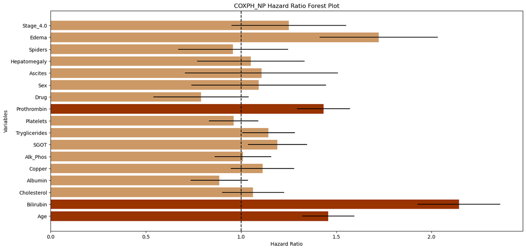

```python
##################################
# Plotting the hazard ratio of the
# formulated Cox Regression model
# with No Penalty
##################################
cirrhosis_survival_coxph_L1_0_L2_0_summary = cirrhosis_survival_coxph_L1_0_L2_0.summary
cirrhosis_survival_coxph_L1_0_L2_0_summary['hazard_ratio'] = np.exp(cirrhosis_survival_coxph_L1_0_L2_0_summary['coef'])
significant = cirrhosis_survival_coxph_L1_0_L2_0_summary['p'] < 0.05
plt.figure(figsize=(17, 8))
colors = ['#993300' if sig else '#CC9966' for sig in significant]

plt.barh(cirrhosis_survival_coxph_L1_0_L2_0_summary.index,
         cirrhosis_survival_coxph_L1_0_L2_0_summary['hazard_ratio'],
         xerr=cirrhosis_survival_coxph_L1_0_L2_0_summary['se(coef)'],
         color=colors)
plt.xlabel('Hazard Ratio')
plt.ylabel('Variables')
plt.title('COXPH_NP Hazard Ratio Forest Plot')
plt.axvline(x=1, color='k', linestyle='--')
plt.show()
```

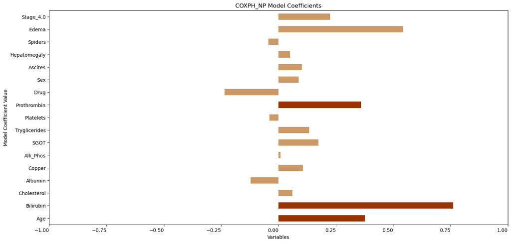

```python
##################################
# Plotting the coefficient magnitude
# of the formulated Cox Regression model
# with No Penalty
##################################
plt.figure(figsize=(17, 8))
colors = ['#993300' if sig else '#CC9966' for sig in significant]
cirrhosis_survival_coxph_L1_0_L2_0_summary['coef'].plot(kind='barh', color=colors)
plt.xlabel('Variables')
plt.ylabel('Model Coefficient Value')
plt.title('COXPH_NP Model Coefficients')
plt.xticks(rotation=0, ha='right')
plt.xlim(-1,1)
plt.show()
```

```python
##################################
# Gathering the apparent model performance
# as baseline for evaluating overfitting
##################################
cirrhosis_survival_coxph_L1_0_L2_0.fit(cirrhosis_survival_train_modeling, duration_col='N_Days', event_col='Status')
train_predictions = cirrhosis_survival_coxph_L1_0_L2_0.predict_partial_hazard(cirrhosis_survival_train_modeling)
cirrhosis_survival_coxph_L1_0_L2_0_train_ci_mean = concordance_index(cirrhosis_survival_train_modeling['N_Days'],
                                                                     -train_predictions,
                                                                     cirrhosis_survival_train_modeling['Status'])
display(f"Apparent Concordance Index: {cirrhosis_survival_coxph_L1_0_L2_0_train_ci_mean}")
```

```
'Apparent Concordance Index: 0.8478543563068921'
```

```python
##################################
# Performing 5-Fold Cross-Validation
# on the training data
##################################
kf = KFold(n_splits=5, shuffle=True, random_state=88888888)
c_index_scores = []

for train_index, val_index in kf.split(cirrhosis_survival_train_modeling):
    df_train_fold = cirrhosis_survival_train_modeling.iloc[train_index]
    df_val_fold = cirrhosis_survival_train_modeling.iloc[val_index]

    cirrhosis_survival_coxph_L1_0_L2_0.fit(df_train_fold, duration_col='N_Days', event_col='Status')
    val_predictions = cirrhosis_survival_coxph_L1_0_L2_0.predict_partial_hazard(df_val_fold)
    c_index = concordance_index(df_val_fold['N_Days'], -val_predictions, df_val_fold['Status'])
    c_index_scores.append(c_index)

cirrhosis_survival_coxph_L1_0_L2_0_cv_ci_mean = np.mean(c_index_scores)
cirrhosis_survival_coxph_L1_0_L2_0_cv_ci_std = np.std(c_index_scores)

display(f"Cross-Validated Concordance Index: {cirrhosis_survival_coxph_L1_0_L2_0_cv_ci_mean}")
```

```
'Cross-Validated Concordance Index: 0.8023642721538025'
```

```python
##################################
# Evaluating the model performance
# on test data
##################################
test_predictions = cirrhosis_survival_coxph_L1_0_L2_0.predict_partial_hazard(cirrhosis_survival_test_modeling)
cirrhosis_survival_coxph_L1_0_L2_0_test_ci_mean = concordance_index(cirrhosis_survival_test_modeling['N_Days'],
                                                                     -test_predictions,
                                                                     cirrhosis_survival_test_modeling['Status'])
display(f"Test Concordance Index: {cirrhosis_survival_coxph_L1_0_L2_0_test_ci_mean}")
```

```
'Test Concordance Index: 0.8480725623582767'
```

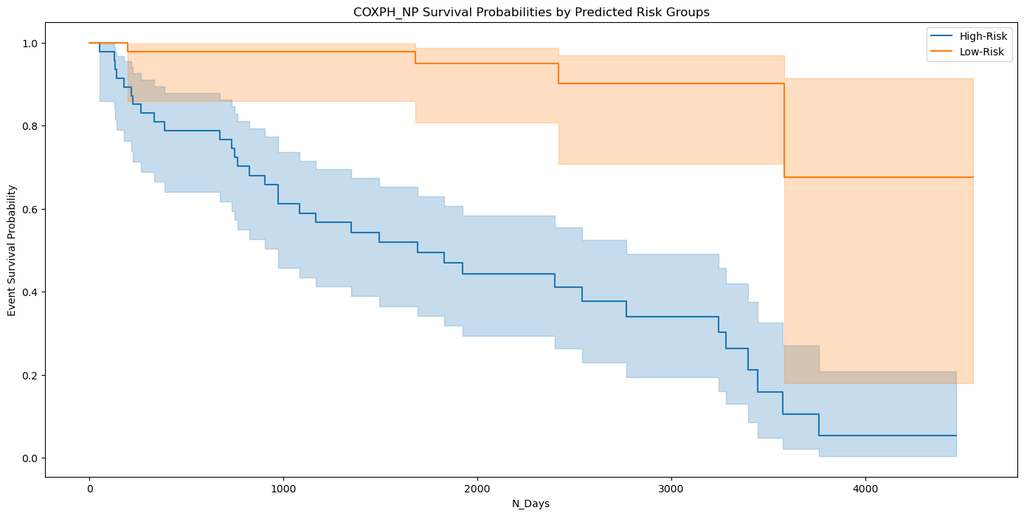

```python
##################################
# Binning the predicted risks
# into dichotomous groups and
# exploring the relationships with
# survival event and duration
##################################
cirrhosis_survival_test_modeling['Predicted_Risks_COXPH_NP'] = test_predictions
cirrhosis_survival_test_modeling['Predicted_RiskGroups_COXPH_NP'] = risk_groups = pd.qcut(cirrhosis_survival_test_modeling['Predicted_Risks_COXPH_NP'], 2, labels=['Low-Risk', 'High-Risk'])

plt.figure(figsize=(17, 8))
for group in risk_groups.unique():
    group_data = cirrhosis_survival_test_modeling[risk_groups == group]
    kmf.fit(group_data['N_Days'], event_observed=group_data['Status'], label=group)
    kmf.plot_survival_function()

plt.title('COXPH_NP Survival Probabilities by Predicted Risk Groups')
plt.xlabel('N_Days')
plt.ylabel('Event Survival Probability')
plt.show()
```

```python
##################################
# Gathering the predictor information
# for 5 test case samples
##################################
test_case_details = cirrhosis_survival_test_modeling.iloc[[0,1,10, 20, 30, 40, 50]]
display(test_case_details)
```

|  | Status | N_Days | Age | Bilirubin | Cholesterol | Albumin | Copper | Alk_Phos | SGOT | Tryglicerides | ... | Prothrombin | Drug | Sex | Ascites | Hepatomegaly | Spiders | Edema | Stage_4.0 | Predicted_Risks_COXPH_NP | Predicted_RiskGroups_COXPH_NP |
| --- | --- | --- | --- | --- | --- | --- | --- | --- | --- | --- | --- | --- | --- | --- | --- | --- | --- | --- | --- | --- | --- |
| 0 | False | 3336 | 1.043704 | 0.744396 | 0.922380 | 0.240951 | 0.045748 | 0.317282 | -0.078335 | 2.671950 | ... | -0.948196 | 1 | 1 | 0 | 0 | 1 | 1 | 0 | 4.640359 | High-Risk |
| 1 | False | 1321 | -1.936476 | -0.764558 | 0.160096 | -0.600950 | -0.179138 | -0.245613 | 0.472422 | -0.359800 | ... | 0.439089 | 0 | 1 | 0 | 0 | 0 | 0 | 1 | 0.321064 | Low-Risk |
| 10 | True | 1827 | 0.226982 | 1.530100 | 1.302295 | 1.331981 | 1.916467 | -0.477846 | -0.451305 | 2.250260 | ... | 0.546417 | 1 | 1 | 0 | 1 | 1 | 0 | 1 | 8.397958 | High-Risk |
| 20 | False | 1447 | -0.147646 | 0.061189 | 0.793618 | -1.158235 | 0.861264 | 0.625621 | 0.319035 | 0.446026 | ... | -1.508571 | 1 | 1 | 0 | 0 | 0 | 0 | 1 | 0.466233 | Low-Risk |
| 30 | False | 2574 | 0.296370 | -1.283677 | 0.169685 | 3.237777 | -1.008276 | -0.873566 | -0.845549 | -0.351236 | ... | -0.617113 | 1 | 1 | 0 | 0 | 0 | 0 | 0 | 0.153047 | Low-Risk |
| 40 | True | 3762 | 0.392609 | -0.096645 | -0.486337 | 1.903146 | -0.546292 | -0.247141 | -0.720619 | -0.810790 | ... | 1.402075 | 0 | 1 | 0 | 1 | 1 | 0 | 1 | 2.224881 | High-Risk |
| 50 | False | 837 | -0.813646 | 1.089037 | 0.064451 | 0.212865 | 2.063138 | -0.224432 | 0.074987 | 2.333282 | ... | -1.125995 | 0 | 1 | 0 | 1 | 1 | 0 | 1 | 2.886051 | High-Risk |

7 rows × 21 columns

```python
##################################
# Gathering the risk-groups
# for 5 test case samples
##################################
print(cirrhosis_survival_test_modeling.loc[[10, 20, 30, 40, 50]][['Predicted_RiskGroups_COXPH_NP']])
```

```
   Predicted_RiskGroups_COXPH_NP
10                     High-Risk
20                      Low-Risk
30                      Low-Risk
40                     High-Risk
50                     High-Risk
```

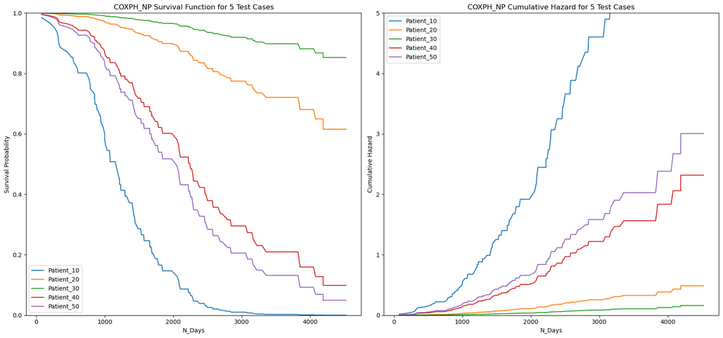

```python
##################################
# Estimating the cumulative hazard
# and survival functions
# for 5 test cases
##################################
test_case = cirrhosis_survival_test_modeling.iloc[[10, 20, 30, 40, 50]]
test_case_labels = ['Patient_10','Patient_20','Patient_30','Patient_40','Patient_50']

fig, axes = plt.subplots(1, 2, figsize=(17, 8))
for i, (index, row) in enumerate(test_case.iterrows()):
    survival_function = cirrhosis_survival_coxph_L1_0_L2_0.predict_survival_function(row.to_frame().T)
    axes[0].plot(survival_function, label=f'Sample {i+1}')
axes[0].set_title('COXPH_NP Survival Function for 5 Test Cases')
axes[0].set_xlabel('N_Days')
axes[0].set_ylim(0,1)
axes[0].set_ylabel('Survival Probability')
axes[0].legend(test_case_labels, loc="lower left")
for i, (index, row) in enumerate(test_case.iterrows()):
    hazard_function = cirrhosis_survival_coxph_L1_0_L2_0.predict_cumulative_hazard(row.to_frame().T)
    axes[1].plot(hazard_function, label=f'Sample {i+1}')
axes[1].set_title('COXPH_NP Cumulative Hazard for 5 Test Cases')
axes[1].set_xlabel('N_Days')
axes[1].set_ylim(0,5)
axes[1].set_ylabel('Cumulative Hazard')
axes[1].legend(test_case_labels, loc="upper left")
plt.tight_layout()
plt.show()
```

```python
##################################
# Creating the explainer object
##################################
cirrhosis_survival_coxph_L1_0_L2_0_explainer = shap.Explainer(cirrhosis_survival_coxph_L1_0_L2_0.predict_partial_hazard,
                                                    cirrhosis_survival_train_modeling.drop(columns=["N_Days", "Status"]))
cirrhosis_survival_coxph_L1_0_L2_0_shap_values = cirrhosis_survival_coxph_L1_0_L2_0_explainer(cirrhosis_survival_train_modeling.drop(columns=["N_Days", "Status"]))
```

```
PermutationExplainer explainer: 219it [00:27,  6.52it/s]
```

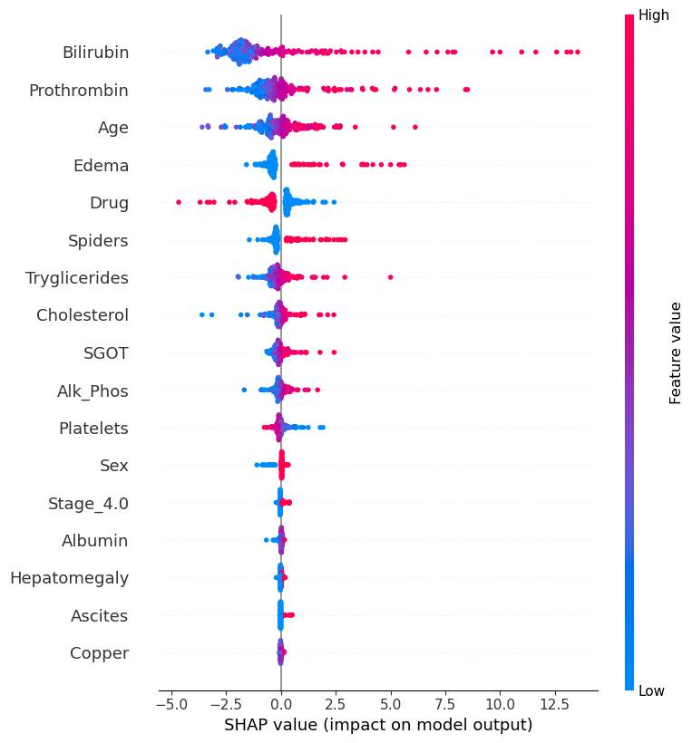

```python
##################################
# Plotting the SHAP summary plot
##################################
shap.summary_plot(cirrhosis_survival_coxph_L1_0_L2_0_shap_values,
                  cirrhosis_survival_train_modeling.drop(columns=["N_Days", "Status"]))
```

### 1.6.3 Cox Regression With Full L1 Penalty

```python
##################################
# Formulating the Cox Regression model
# with Full L1 Penalty and generating the summary
##################################
cirrhosis_survival_coxph_L1_100_L2_0 = CoxPHFitter(penalizer=0.1, l1_ratio=1.0)
cirrhosis_survival_coxph_L1_100_L2_0.fit(cirrhosis_survival_train_modeling, duration_col='N_Days', event_col='Status')
cirrhosis_survival_coxph_L1_100_L2_0.summary
```

| covariate | coef | exp(coef) | se(coef) | coef lower 95% | coef upper 95% | exp(coef) lower 95% | exp(coef) upper 95% | cmp to | z | p | -log2(p) |
| --- | --- | --- | --- | --- | --- | --- | --- | --- | --- | --- | --- |
| Age | 1.019423e-01 | 1.107320 | 0.113381 | -0.120280 | 0.324165 | 0.886672 | 1.382875 | 0.0 | 0.899114 | 0.368592 | 1.439903 |
| Bilirubin | 7.205550e-01 | 2.055574 | 0.155250 | 0.416270 | 1.024840 | 1.516295 | 2.786650 | 0.0 | 4.641247 | 0.000003 | 18.139495 |
| Cholesterol | 8.673029e-09 | 1.000000 | 0.000078 | -0.000153 | 0.000153 | 0.999847 | 1.000153 | 0.0 | 0.000111 | 0.999911 | 0.000128 |
| Albumin | -5.899624e-02 | 0.942710 | 0.132000 | -0.317712 | 0.199719 | 0.727813 | 1.221060 | 0.0 | -0.446941 | 0.654918 | 0.610614 |
| Copper | 2.602826e-02 | 1.026370 | 0.133726 | -0.236070 | 0.288127 | 0.789725 | 1.333926 | 0.0 | 0.194639 | 0.845676 | 0.241823 |
| Alk_Phos | 6.649722e-08 | 1.000000 | 0.000088 | -0.000172 | 0.000172 | 0.999828 | 1.000172 | 0.0 | 0.000757 | 0.999396 | 0.000872 |
| SGOT | 1.196063e-07 | 1.000000 | 0.000112 | -0.000219 | 0.000219 | 0.999781 | 1.000219 | 0.0 | 0.001069 | 0.999147 | 0.001232 |
| Tryglicerides | 1.859293e-07 | 1.000000 | 0.000168 | -0.000329 | 0.000330 | 0.999671 | 1.000330 | 0.0 | 0.001106 | 0.999118 | 0.001273 |
| Platelets | -1.591429e-07 | 1.000000 | 0.000141 | -0.000277 | 0.000277 | 0.999723 | 1.000277 | 0.0 | -0.001127 | 0.999101 | 0.001298 |
| Prothrombin | 2.106760e-01 | 1.234512 | 0.130005 | -0.044129 | 0.465481 | 0.956830 | 1.592780 | 0.0 | 1.620523 | 0.105120 | 3.249890 |
| Drug | -2.885452e-08 | 1.000000 | 0.000157 | -0.000308 | 0.000308 | 0.999692 | 1.000308 | 0.0 | -0.000184 | 0.999853 | 0.000212 |
| Sex | -2.332571e-07 | 1.000000 | 0.000274 | -0.000538 | 0.000537 | 0.999462 | 1.000537 | 0.0 | -0.000851 | 0.999321 | 0.000979 |
| Ascites | 1.608914e-01 | 1.174557 | 0.410628 | -0.643925 | 0.965708 | 0.525227 | 2.626647 | 0.0 | 0.391818 | 0.695193 | 0.524514 |
| Hepatomegaly | 3.202570e-07 | 1.000000 | 0.000284 | -0.000557 | 0.000557 | 0.999443 | 1.000558 | 0.0 | 0.001127 | 0.999101 | 0.001298 |
| Spiders | 1.774944e-07 | 1.000000 | 0.000208 | -0.000407 | 0.000408 | 0.999593 | 1.000408 | 0.0 | 0.000854 | 0.999319 | 0.000983 |
| Edema | 1.676711e-01 | 1.182548 | 0.315894 | -0.451471 | 0.786813 | 0.636691 | 2.196385 | 0.0 | 0.530782 | 0.595570 | 0.747657 |
| Stage_4.0 | 3.156528e-02 | 1.032069 | 0.270735 | -0.499066 | 0.562196 | 0.607098 | 1.754521 | 0.0 | 0.116591 | 0.907184 | 0.140533 |

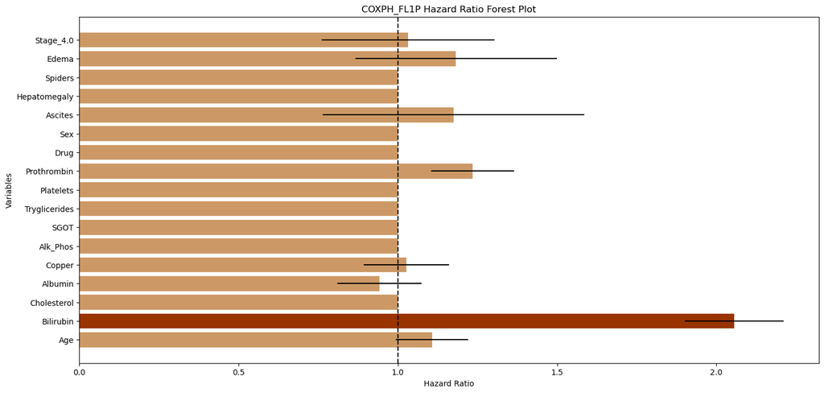

```python
##################################
# Plotting the hazard ratio of the
# formulated Cox Regression model
# with Full L1 Penalty
##################################
cirrhosis_survival_coxph_L1_100_L2_0_summary = cirrhosis_survival_coxph_L1_100_L2_0.summary
cirrhosis_survival_coxph_L1_100_L2_0_summary['hazard_ratio'] = np.exp(cirrhosis_survival_coxph_L1_100_L2_0_summary['coef'])
significant = cirrhosis_survival_coxph_L1_100_L2_0_summary['p'] < 0.05
plt.figure(figsize=(17, 8))
colors = ['#993300' if sig else '#CC9966' for sig in significant]

plt.barh(cirrhosis_survival_coxph_L1_100_L2_0_summary.index,
         cirrhosis_survival_coxph_L1_100_L2_0_summary['hazard_ratio'],
         xerr=cirrhosis_survival_coxph_L1_100_L2_0_summary['se(coef)'],
         color=colors)
plt.xlabel('Hazard Ratio')
plt.ylabel('Variables')
plt.title('COXPH_FL1P Hazard Ratio Forest Plot')
plt.axvline(x=1, color='k', linestyle='--')
plt.show()
```

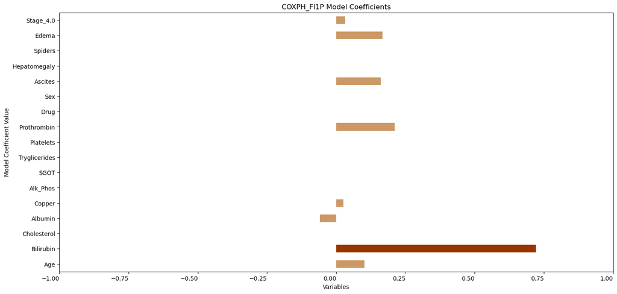

```python
##################################
# Plotting the coefficient magnitude
# of the formulated Cox Regression model
# with Full L1 Penalty
##################################
plt.figure(figsize=(17, 8))
colors = ['#993300' if sig else '#CC9966' for sig in significant]
cirrhosis_survival_coxph_L1_100_L2_0_summary['coef'].plot(kind='barh', color=colors)
plt.xlabel('Variables')
plt.ylabel('Model Coefficient Value')
plt.title('COXPH_Fl1P Model Coefficients')
plt.xticks(rotation=0, ha='right')
plt.xlim(-1,1)
plt.show()
```

```python
##################################
# Gathering the apparent model performance
# as baseline for evaluating overfitting
##################################
cirrhosis_survival_coxph_L1_100_L2_0.fit(cirrhosis_survival_train_modeling, duration_col='N_Days', event_col='Status')
train_predictions = cirrhosis_survival_coxph_L1_100_L2_0.predict_partial_hazard(cirrhosis_survival_train_modeling)
cirrhosis_survival_coxph_L1_100_L2_0_train_ci_mean = concordance_index(cirrhosis_survival_train_modeling['N_Days'],
                                                                     -train_predictions,
                                                                     cirrhosis_survival_train_modeling['Status'])
display(f"Apparent Concordance Index: {cirrhosis_survival_coxph_L1_100_L2_0_train_ci_mean}")
```

```
'Apparent Concordance Index: 0.8313556566970091'
```

```python
##################################
# Performing 5-Fold Cross-Validation
# on the training data
##################################
kf = KFold(n_splits=5, shuffle=True, random_state=88888888)
c_index_scores = []

for train_index, val_index in kf.split(cirrhosis_survival_train_modeling):
    df_train_fold = cirrhosis_survival_train_modeling.iloc[train_index]
    df_val_fold = cirrhosis_survival_train_modeling.iloc[val_index]

    cirrhosis_survival_coxph_L1_100_L2_0.fit(df_train_fold, duration_col='N_Days', event_col='Status')
    val_predictions = cirrhosis_survival_coxph_L1_100_L2_0.predict_partial_hazard(df_val_fold)
    c_index = concordance_index(df_val_fold['N_Days'], -val_predictions, df_val_fold['Status'])
    c_index_scores.append(c_index)

cirrhosis_survival_coxph_L1_100_L2_0_cv_ci_mean = np.mean(c_index_scores)
cirrhosis_survival_coxph_L1_100_L2_0_cv_ci_std = np.std(c_index_scores)

display(f"Cross-Validated Concordance Index: {cirrhosis_survival_coxph_L1_100_L2_0_cv_ci_mean}")
```

```
'Cross-Validated Concordance Index: 0.8111973914136674'
```

```python
##################################
# Evaluating the model performance
# on test data
##################################
test_predictions = cirrhosis_survival_coxph_L1_100_L2_0.predict_partial_hazard(cirrhosis_survival_test_modeling)
cirrhosis_survival_coxph_L1_100_L2_0_test_ci_mean = concordance_index(cirrhosis_survival_test_modeling['N_Days'],
                                                                     -test_predictions,
                                                                     cirrhosis_survival_test_modeling['Status'])
display(f"Test Concordance Index: {cirrhosis_survival_coxph_L1_100_L2_0_test_ci_mean}")
```

```
'Test Concordance Index: 0.8426303854875283'
```

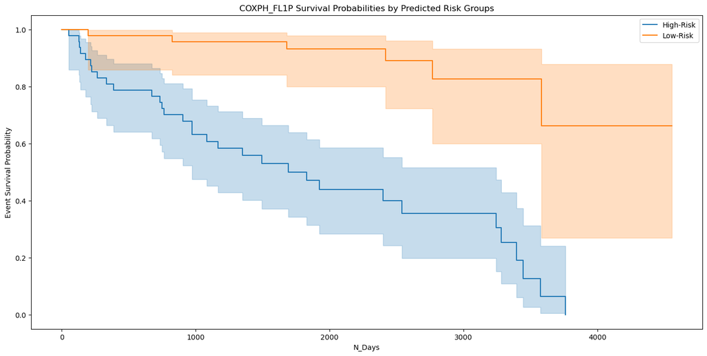

```python
##################################
# Binning the predicted risks
# into dichotomous groups and
# exploring the relationships with
# survival event and duration
##################################
cirrhosis_survival_test_modeling['Predicted_Risks_COXPH_FL1P'] = test_predictions
cirrhosis_survival_test_modeling['Predicted_RiskGroups_COXPH_FL1P'] = risk_groups = pd.qcut(cirrhosis_survival_test_modeling['Predicted_Risks_COXPH_FL1P'], 2, labels=['Low-Risk', 'High-Risk'])

plt.figure(figsize=(17, 8))
for group in risk_groups.unique():
    group_data = cirrhosis_survival_test_modeling[risk_groups == group]
    kmf.fit(group_data['N_Days'], event_observed=group_data['Status'], label=group)
    kmf.plot_survival_function()

plt.title('COXPH_FL1P Survival Probabilities by Predicted Risk Groups')
plt.xlabel('N_Days')
plt.ylabel('Event Survival Probability')
plt.show()
```

```python
##################################
# Gathering the predictor information
# for 5 test case samples
##################################
test_case_details = cirrhosis_survival_test_modeling.iloc[[0,1,10, 20, 30, 40, 50]]
display(test_case_details)
```

|  | Status | N_Days | Age | Bilirubin | Cholesterol | Albumin | Copper | Alk_Phos | SGOT | Tryglicerides | ... | Sex | Ascites | Hepatomegaly | Spiders | Edema | Stage_4.0 | Predicted_Risks_COXPH_NP | Predicted_RiskGroups_COXPH_NP | Predicted_Risks_COXPH_FL1P | Predicted_RiskGroups_COXPH_FL1P |
| --- | --- | --- | --- | --- | --- | --- | --- | --- | --- | --- | --- | --- | --- | --- | --- | --- | --- | --- | --- | --- | --- |
| 0 | False | 3336 | 1.043704 | 0.744396 | 0.922380 | 0.240951 | 0.045748 | 0.317282 | -0.078335 | 2.671950 | ... | 1 | 0 | 0 | 1 | 1 | 0 | 4.640359 | High-Risk | 1.957525 | High-Risk |
| 1 | False | 1321 | -1.936476 | -0.764558 | 0.160096 | -0.600950 | -0.179138 | -0.245613 | 0.472422 | -0.359800 | ... | 1 | 0 | 0 | 0 | 0 | 1 | 0.321064 | Low-Risk | 0.582238 | Low-Risk |
| 10 | True | 1827 | 0.226982 | 1.530100 | 1.302295 | 1.331981 | 1.916467 | -0.477846 | -0.451305 | 2.250260 | ... | 1 | 0 | 1 | 1 | 0 | 1 | 8.397958 | High-Risk | 3.515780 | High-Risk |
| 20 | False | 1447 | -0.147646 | 0.061189 | 0.793618 | -1.158235 | 0.861264 | 0.625621 | 0.319035 | 0.446026 | ... | 1 | 0 | 0 | 0 | 0 | 1 | 0.466233 | Low-Risk | 0.769723 | Low-Risk |
| 30 | False | 2574 | 0.296370 | -1.283677 | 0.169685 | 3.237777 | -1.008276 | -0.873566 | -0.845549 | -0.351236 | ... | 1 | 0 | 0 | 0 | 0 | 0 | 0.153047 | Low-Risk | 0.320200 | Low-Risk |
| 40 | True | 3762 | 0.392609 | -0.096645 | -0.486337 | 1.903146 | -0.546292 | -0.247141 | -0.720619 | -0.810790 | ... | 1 | 0 | 1 | 1 | 0 | 1 | 2.224881 | High-Risk | 1.167777 | High-Risk |
| 50 | False | 837 | -0.813646 | 1.089037 | 0.064451 | 0.212865 | 2.063138 | -0.224432 | 0.074987 | 2.333282 | ... | 1 | 0 | 1 | 1 | 0 | 1 | 2.886051 | High-Risk | 1.832490 | High-Risk |

7 rows × 23 columns

```python
##################################
# Gathering the risk-groups
# for 5 test case samples
##################################
print(cirrhosis_survival_test_modeling.loc[[10, 20, 30, 40, 50]][['Predicted_RiskGroups_COXPH_FL1P']])
```

```
   Predicted_RiskGroups_COXPH_FL1P
10                       High-Risk
20                        Low-Risk
30                        Low-Risk
40                       High-Risk
50                       High-Risk
```

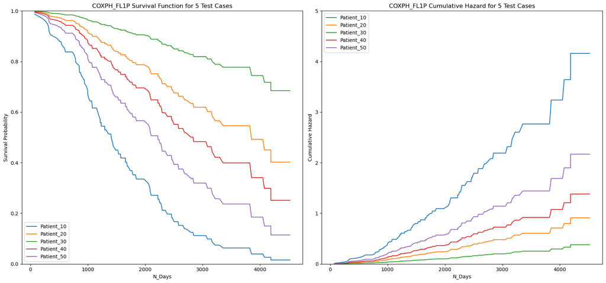

```python
##################################
# Estimating the cumulative hazard
# and survival functions
# for 5 test cases
##################################
test_case = cirrhosis_survival_test_modeling.iloc[[10, 20, 30, 40, 50]]
test_case_labels = ['Patient_10','Patient_20','Patient_30','Patient_40','Patient_50']

fig, axes = plt.subplots(1, 2, figsize=(17, 8))
for i, (index, row) in enumerate(test_case.iterrows()):
    survival_function = cirrhosis_survival_coxph_L1_100_L2_0.predict_survival_function(row.to_frame().T)
    axes[0].plot(survival_function, label=f'Sample {i+1}')
axes[0].set_title('COXPH_FL1P Survival Function for 5 Test Cases')
axes[0].set_xlabel('N_Days')
axes[0].set_ylim(0,1)
axes[0].set_ylabel('Survival Probability')
axes[0].legend(test_case_labels, loc="lower left")
for i, (index, row) in enumerate(test_case.iterrows()):
    hazard_function = cirrhosis_survival_coxph_L1_100_L2_0.predict_cumulative_hazard(row.to_frame().T)
    axes[1].plot(hazard_function, label=f'Sample {i+1}')
axes[1].set_title('COXPH_FL1P Cumulative Hazard for 5 Test Cases')
axes[1].set_xlabel('N_Days')
axes[1].set_ylim(0,5)
axes[1].set_ylabel('Cumulative Hazard')
axes[1].legend(test_case_labels, loc="upper left")
plt.tight_layout()
plt.show()
```

```python
##################################
# Creating the explainer object
##################################
cirrhosis_survival_coxph_L1_100_L2_0_explainer = shap.Explainer(cirrhosis_survival_coxph_L1_100_L2_0.predict_partial_hazard,
                                                    cirrhosis_survival_train_modeling.drop(columns=["N_Days", "Status"]))
cirrhosis_survival_coxph_L1_100_L2_0_shap_values = cirrhosis_survival_coxph_L1_100_L2_0_explainer(cirrhosis_survival_train_modeling.drop(columns=["N_Days", "Status"]))
```

```
PermutationExplainer explainer: 219it [00:17,  4.68it/s]
```

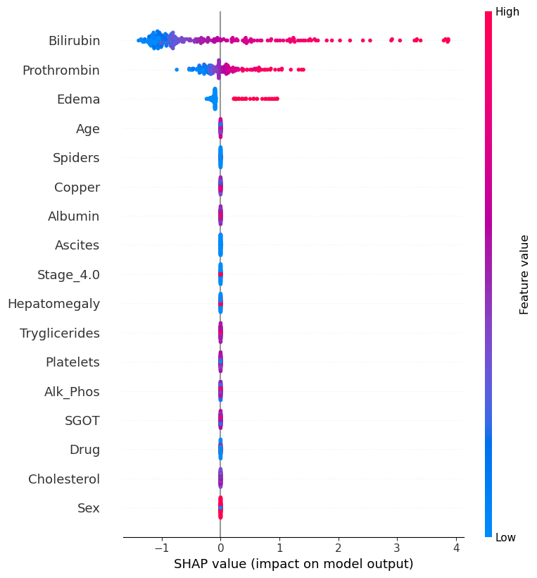

```python
##################################
# Plotting the SHAP summary plot
##################################
shap.summary_plot(cirrhosis_survival_coxph_L1_100_L2_0_shap_values,
                  cirrhosis_survival_train_modeling.drop(columns=["N_Days", "Status"]))
```

### 1.6.4 Cox Regression With Full L2 Penalty

### 1.6.5 Cox Regression With Equal L1|L2 Penalty

### 1.6.6 Cox Regression With Predominantly L1-Weighted|L2 Penalty

### 1.6.7 Cox Regression With Predominantly L2-Weighted|L1 Penalty

## 1.7. Consolidated Findings

# 2. Summary

# 3. References

- **[Book]** [Clinical Prediction Models](http://clinicalpredictionmodels.org/) by Ewout Steyerberg
- **[Book]** [Survival Analysis: A Self-Learning Text](https://link.springer.com/book/10.1007/978-1-4419-6646-9/) by David Kleinbaum and Mitchel Klein
- **[Book]** [Applied Survival Analysis Using R](https://link.springer.com/book/10.1007/978-3-319-31245-3/) by Dirk Moore
- **[Python Library API]** [SciKit-Survival](https://pypi.org/project/scikit-survival/) by SciKit-Survival Team
- **[Python Library API]** [SciKit-Learn](https://scikit-learn.org/stable/index.html) by SciKit-Learn Team
- **[Python Library API]** [StatsModels](https://www.statsmodels.org/stable/index.html) by StatsModels Team
- **[Python Library API]** [SciPy](https://scipy.org/) by SciPy Team
- **[Python Library API]** [Lifelines](https://lifelines.readthedocs.io/en/latest/) by Lifelines Team
- **[Article]** [Exploring Time-to-Event with Survival Analysis](https://towardsdatascience.com/exploring-time-to-event-with-survival-analysis-8b0a7a33a7be) by Olivia Tanuwidjaja (Towards Data Science)
- **[Article]** [The Complete Introduction to Survival Analysis in Python](https://towardsdatascience.com/the-complete-introduction-to-survival-analysis-in-python-7523e17737e6) by Marco Peixeiro (Towards Data Science)
- **[Article]** [Survival Analysis Simplified: Explaining and Applying with Python](https://medium.com/@zynp.atlii/survival-analysis-simplified-explaining-and-applying-with-python-7efacf86ba32) by Zeynep Atli (Towards Data Science)
- **[Article]** [Survival Analysis in Python (KM Estimate, Cox-PH and AFT Model)](https://medium.com/the-researchers-guide/survival-analysis-in-python-km-estimate-cox-ph-and-aft-model-5533843c5d5d) by Rahul Raoniar (Medium)
- **[Article]** [How to Evaluate Survival Analysis Models)](https://towardsdatascience.com/how-to-evaluate-survival-analysis-models-dd67bc10caae) by Nicolo Cosimo Albanese (Towards Data Science)
- **[Article]** [Survival Analysis with Python Tutorial — How, What, When, and Why)](https://pub.towardsai.net/survival-analysis-with-python-tutorial-how-what-when-and-why-19a5cfb3c312) by Towards AI Team (Medium)
- **[Article]** [Survival Analysis: Predict Time-To-Event With Machine Learning)](https://towardsdatascience.com/survival-analysis-predict-time-to-event-with-machine-learning-part-i-ba52f9ab9a46) by Lina Faik (Medium)
- **[Article]** [A Complete Guide To Survival Analysis In Python, Part 1](https://www.kdnuggets.com/2020/07/complete-guide-survival-analysis-python-part1.html) by Pratik Shukla (KDNuggets)
- **[Article]** [A Complete Guide To Survival Analysis In Python, Part 2](https://www.kdnuggets.com/2020/07/guide-survival-analysis-python-part-2.html) by Pratik Shukla (KDNuggets)
- **[Article]** [A Complete Guide To Survival Analysis In Python, Part 3](https://www.kdnuggets.com/2020/07/guide-survival-analysis-python-part-3.html) by Pratik Shukla (KDNuggets)
- **[Article]** [Model Explainability using SHAP (SHapley Additive exPlanations) and LIME (Local Interpretable Model-agnostic Explanations)](https://medium.com/@anshulgoel991/model-exploitability-using-shap-shapley-additive-explanations-and-lime-local-interpretable-cb4f5594fc1a) by Anshul Goel (Medium)
- **[Article]** [A Comprehensive Guide into SHAP (SHapley Additive exPlanations) Values](https://www.kdnuggets.com/2020/07/guide-survival-analysis-python-part-3.html) by Brain John Aboze (DeepChecks.Com)
- **[Article]** [SHAP - Understanding How This Method for Explainable AI Works](https://safjan.com/how-the-shap-method-for-explainable-ai-works/#google_vignette) by Krystian Safjan (Safjan.Com)
- **[Article]** [SHAP: Shapley Additive Explanations](https://towardsdatascience.com/shap-shapley-additive-explanations-5a2a271ed9c3) by Fernando Lopez (Medium)
- **[Article]** [Explainable Machine Learning, Game Theory, and Shapley Values: A technical review](https://www.kdnuggets.com/2020/07/guide-survival-analysis-python-part-3.html) by Soufiane Fadel (Statistics Canada)
- **[Article]** [SHAP Values Explained Exactly How You Wished Someone Explained to You](https://towardsdatascience.com/shap-explained-the-way-i-wish-someone-explained-it-to-me-ab81cc69ef30) by Samuele Mazzanti (Towards Data Science)
- **[Article]** [Explaining Machine Learning Models: A Non-Technical Guide to Interpreting SHAP Analyses](https://www.aidancooper.co.uk/a-non-technical-guide-to-interpreting-shap-analyses/) by Aidan Cooper (AidanCooper.Co.UK)
- **[Article]** [Shapley Additive Explanations: Unveiling the Black Box of Machine Learning](https://python.plainenglish.io/shapley-additive-explanations-unveiling-the-black-box-of-machine-learning-477ba01ffa07) by Evertone Gomede (Medium)
- **[Article]** [SHAP (SHapley Additive exPlanations)](https://www.nerd-data.com/shap/) by Narut Soontranon (Nerd-Data.Com)
- **[Kaggle Project]** [Survival Analysis with Cox Model Implementation](https://www.kaggle.com/code/bryanb/survival-analysis-with-cox-model-implementation/notebook) by Bryan Boulé (Kaggle)
- **[Kaggle Project]** [Survival Analysis](https://www.kaggle.com/code/gunesevitan/survival-analysis/notebook) by Gunes Evitan (Kaggle)
- **[Kaggle Project]** [Survival Analysis of Lung Cancer Patients](https://www.kaggle.com/code/bryanb/survival-analysis-with-cox-model-implementation/notebook) by Sayan Chakraborty (Kaggle)
- **[Kaggle Project]** [COVID-19 Cox Survival Regression](https://www.kaggle.com/code/bryanb/survival-analysis-with-cox-model-implementation/notebook) by Ilias Katsabalos (Kaggle)
- **[Kaggle Project]** [Liver Cirrhosis Prediction with XGboost & EDA](https://www.kaggle.com/code/arjunbhaybhang/liver-cirrhosis-prediction-with-xgboost-eda) by Arjun Bhaybang (Kaggle)
- **[Kaggle Project]** [Survival Models VS ML Models Benchmark - Churn Tel](https://www.kaggle.com/code/caralosal/survival-models-vs-ml-models-benchmark-churn-tel) by Carlos Alonso Salcedo (Kaggle)
- **[Publication]** [Regression Models and Life Tables](https://rss.onlinelibrary.wiley.com/doi/abs/10.1111/j.2517-6161.1972.tb00899.x) by David Cox (Royal Statistical Society)
- **[Publication]** [Covariance Analysis of Censored Survival Data](https://pubmed.ncbi.nlm.nih.gov/4813387/) by Norman Breslow (Biometrics)
- **[Publication]** [The Efficiency of Cox’s Likelihood Function for Censored Data](https://www.jstor.org/stable/2286217) by Bradley Efron (Journal of the American Statistical Association)
- **[Publication]** [Regularization Paths for Cox’s Proportional Hazards Model via Coordinate Descent](https://doi.org/10.18637/jss.v039.i05) by Noah Simon, Jerome Friedman, Trevor Hastie and Rob Tibshirani (Journal of Statistical Software)
- **[Publication]** [Shapley Additive Explanations](https://dl.acm.org/doi/10.5555/1756006.1756007) by Noah Simon, Jerome Friedman, Trevor Hastie and Rob Tibshirani (Journal of Statistical Software) by Erik Strumbelj and Igor Kononenko (The Journal of Machine Learning Research)
- **[Publication]** [A Unified Approach to Interpreting Model Predictions](https://proceedings.neurips.cc/paper_files/paper/2017/file/8a20a8621978632d76c43dfd28b67767-Paper.pdf) by Scott Lundberg and Sun-In Lee (Conference on Neural Information Processing Systems)
- **[Publication]** [Survival Analysis Part I: Basic Concepts and First Analyses](https://www.ncbi.nlm.nih.gov/pmc/articles/PMC2394262/) by Taane Clark (British Journal of Cancer)
- **[Publication]** [Survival Analysis Part II: Multivariate Data Analysis – An Introduction to Concepts and Methods](https://www.ncbi.nlm.nih.gov/pmc/articles/PMC2394368/) by Mike Bradburn (British Journal of Cancer)
- **[Publication]** [Survival Analysis Part III: Multivariate Data Analysis – Choosing a Model and Assessing its Adequacy and Fit](https://www.ncbi.nlm.nih.gov/pmc/articles/PMC2376927/) by Mike Bradburn (British Journal of Cancer)
- **[Publication]** [Survival Analysis Part IV: Further Concepts and Methods in Survival Analysis](https://www.ncbi.nlm.nih.gov/pmc/articles/PMC2394469/) by Taane Clark (British Journal of Cancer)
- **[Course]** [Survival Analysis in Python](https://app.datacamp.com/learn/courses/survival-analysis-in-python) by Shae Wang (DataCamp)

```python
from IPython.display import display, HTML
display(HTML("<style>.rendered_html { font-size: 15px; font-family: 'Trebuchet MS'; }</style>"))
```